# Исследования трендов урожайности зерновых за 1970-2012 годы в Канаде

Max Korolchuk

24 сентября 2016 г

Данные были взяты отсюда  
http://open.canada.ca/en[^1].

## Вступление

Датасет состоит из 60996 измерений в 12 регионах включая общие измерения(по всей Канаде). Для исследование и постановки гипотезы была выбрана урожайность зерновых культур. Так же из исследования был выключен регион Newfoundland and Labrador, так как для него нет данных по нужному нам параметру. Годы наблюдений 1970-2012.

## Постановка гипотезы

Мы заинтересованы в следующей гипотезе: $\Psi_1.$ - изменения урожайности зерновых культур в разных регионах Канады в 1970 - 2012 годах статистически значимо. Для проверки оной гипотезы мы используем **R** версии 3.2.5 и соответствующий статистический тест *t-test* :
$$t = \frac{\overline{x} - \mu_0}{s/\sqrt{n}}.$$

## План исследования

Алгоритм :

1. Считать и обработать подходящий датасет
2. Проверить гипотезу для каждого региона с помощью *t-test*
3. Подкрепить выводы :
- таблицей с полученными результатами;
- графиком, иллюстрирующим результаты для всех регионов частности ;
- таким же графиком для Канады в общем;

## Ход исследования

#### **Таблица с результатами**:

Описательные статистики и доверительные интервалы

| GEO | Pvalue | Confiden_level | Mean_Prod | Lowest_Prod | Highest_Prod | Best_Year | Worst_Year |
| --- | --- | --- | --- | --- | --- | --- | --- |
| Alberta | 0 | 98.18 | 94.99 | 28.8 | 179.0 | 2008 | 1971 |
| Manitoba | 0 | 92.69 | 89.54 | 25.8 | 161.6 | 2008 | 1971 |
| New Brunswick | 0 | 109.06 | 103.91 | 17.2 | 231.0 | 2010 | 1971 |
| Nova Scotia | 0 | 90.57 | 86.39 | 21.7 | 196.1 | 2008 | 1972 |
| Ontario | 0 | 87.30 | 84.71 | 31.7 | 142.9 | 2012 | 1971 |
| Prince Edward Island | 0 | 116.32 | 110.15 | 15.7 | 300.8 | 2007 | 1971 |
| Quebec | 0 | 91.56 | 88.17 | 25.8 | 161.2 | 2011 | 1971 |
| Saskatchewan | 0 | 99.52 | 96.10 | 29.2 | 193.9 | 2008 | 1971 |

## Графики

> График №2

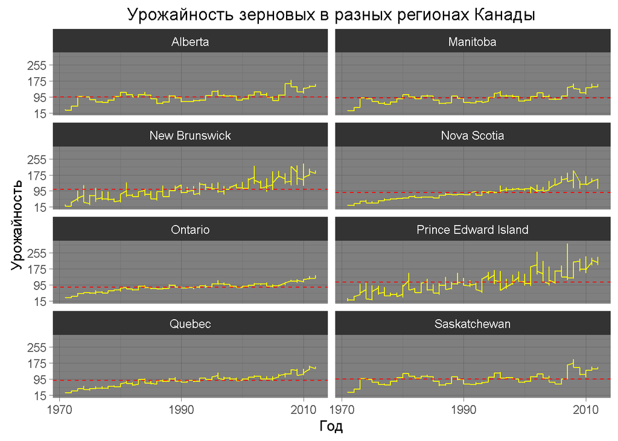

> График 3

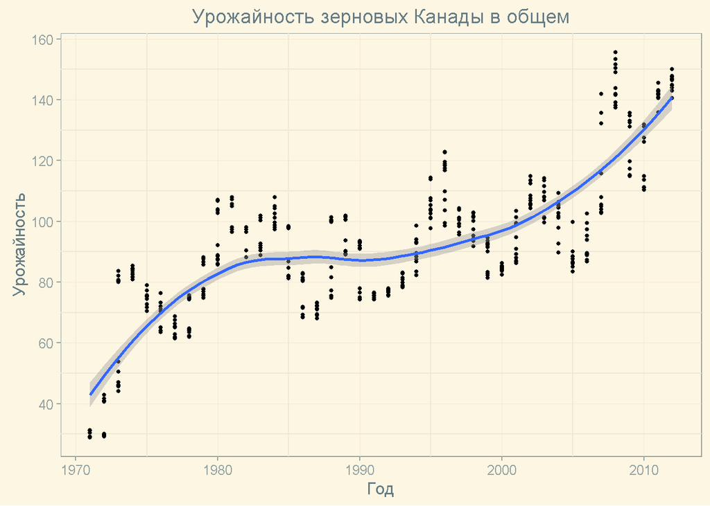

[^1]: Здесь [прямая ссылка](http://open.canada.ca/data/en/dataset/fe4c98ae-5b1a-4a20-814b-545dcbd41c29) на скачивание файла.